# Jyoti_das_updated_AIML_ML_Project_Full_Code_Notebook

## Problem Statement

### Context

AllLife Bank is a mid-sized, fast-growing US-based financial institution that offers a range of retail banking services, including savings and checking accounts, fixed deposits, and personal loans. The bank’s business model is centered on building long-term customer relationships, expanding its retail footprint, and growing its loan portfolio to drive sustainable profitability through interest income.

It currently relies on a large base of liability customers (depositors) but faces a significant under-representation of asset customers (borrowers). To drive profitability through interest income, the bank must aggressively expand its loan portfolio by converting existing depositors into personal loan customers.

Last year’s pilot campaign achieved a 9% conversion rate, validating the potential of this strategy. However, to optimize marketing spend and improve efficiency, the retail marketing department requires a more data-driven approach. Enhancing the success ratio of these campaigns is critical for sustainable growth and maximizing customer lifetime value.

### Objective

The objective is to develop a predictive classification model that identifies patterns and key factors driving personal loan adoption among existing liability customers. By uncovering the demographic and behavioral drivers of loan conversion, the goal is to enable targeted segmentation and more precise marketing interventions that improve campaign conversion rates, optimize marketing spend, and enhance overall profitability through higher-quality loan portfolio growth.

### Data Dictionary

- `ID`: Customer ID
- `Age`: Customer’s age in completed years
- `Experience`: #years of professional experience
- `Income`: Annual income of the customer (in thousand dollars)
- `ZIP Code`: Home Address ZIP code.
- `Family`: the Family size of the customer
- `CCAvg`: Average spending on credit cards per month (in thousand dollars)
- `Education`: Education Level. 1: Undergrad; 2: Graduate;3: Advanced/Professional
- `Mortgage`: Value of house mortgage if any. (in thousand dollars)
- `Personal_Loan`: Did this customer accept the personal loan offered in the last campaign? (0: No, 1: Yes)
- `Securities_Account`: Does the customer have securities account with the bank? (0: No, 1: Yes)
- `CD_Account`: Does the customer have a certificate of deposit (CD) account with the bank? (0: No, 1: Yes)
- `Online`: Do customers use internet banking facilities? (0: No, 1: Yes)
- `CreditCard`: Does the customer use a credit card issued by any other Bank (excluding All life Bank)? (0: No, 1: Yes)

## Importing necessary libraries

```python
# Installing the libraries with the specified version.
!pip install numpy==2.0.2 pandas==2.2.2 matplotlib==3.10.0 seaborn==0.13.2 scikit-learn==1.6.1 sklearn-pandas==2.2.0 -q --user
```

**Note**:

1. After running the above cell, kindly restart the notebook kernel (for Jupyter Notebook) or runtime (for Google Colab), write the relevant code for the project from the next cell, and run all cells sequentially from the next cell.
2. On executing the above line of code, you might see a warning regarding package dependencies. This error message can be ignored as the above code ensures that all necessary libraries and their dependencies are maintained to successfully execute the code in this notebook.

### *Importing the Libaries*

```python
# Libaries to help with reading and manipulating data
import pandas as pd
import numpy as np

# libaries to help with data visualization
import matplotlib.pyplot as plt
import seaborn as sns

# Library to split data
from sklearn.model_selection import train_test_split

# To build model for prediction
from sklearn.tree import DecisionTreeClassifier
from sklearn import tree
from sklearn.linear_model import LogisticRegression # Added import for LogisticRegression

# To get diferent metric scores
from sklearn.metrics import (
    f1_score,
    accuracy_score,
    recall_score,
    precision_score,
    confusion_matrix
)

# to suppress unnecessary warnings
import warnings
warnings.filterwarnings("ignore")
```

## *Loading the dataset and copying the dataset*

```python
# uncomment and run the below code snippets if the dataset is present in the Google Drive
from google.colab import drive
drive.mount('/content/drive')
```

```python
# code to read  the CSV file
Loan= pd.read_csv("/content/drive/MyDrive/UT Course/ML/Loan Campaing/Loan_Modelling.csv")
```

```python
# copying data to another variable to avoid any changes to original data
data = Loan.copy()
```

## Data Overview

- Observations
- Sanity checks

### Observations

During the data overview, we will observe the following:

- **View the dataset**: First and last 5 rows of the dataset.
- **Shape of the data**: Number of rows and columns.
- **Data types**: The type of data in each column (e.g., integer, float, object).
- **Missing values**: Identification of columns with missing data and their extent.
- **Unique values**: Number of unique entries in categorical columns.
- **Descriptive statistics**: Summary statistics for numerical columns (e.g., mean, median, min, max, standard deviation).

## *View the dataset: First and last 5 rows of the dataset.*

```python
#Display first 5 rows of the dataset
data.head(5)
```

|  | ID | Age | Experience | Income | ZIPCode | Family | CCAvg | Education | Mortgage | Personal_Loan | Securities_Account | CD_Account | Online | CreditCard |
| --- | --- | --- | --- | --- | --- | --- | --- | --- | --- | --- | --- | --- | --- | --- |
| 0 | 1 | 25 | 1 | 49 | 91107 | 4 | 1.6 | 1 | 0 | 0 | 1 | 0 | 0 | 0 |
| 1 | 2 | 45 | 19 | 34 | 90089 | 3 | 1.5 | 1 | 0 | 0 | 1 | 0 | 0 | 0 |
| 2 | 3 | 39 | 15 | 11 | 94720 | 1 | 1.0 | 1 | 0 | 0 | 0 | 0 | 0 | 0 |
| 3 | 4 | 35 | 9 | 100 | 94112 | 1 | 2.7 | 2 | 0 | 0 | 0 | 0 | 0 | 0 |
| 4 | 5 | 35 | 8 | 45 | 91330 | 4 | 1.0 | 2 | 0 | 0 | 0 | 0 | 0 | 1 |

```python
#Display last  5 rows of the dataset
data.tail(5)
```

|  | ID | Age | Experience | Income | ZIPCode | Family | CCAvg | Education | Mortgage | Personal_Loan | Securities_Account | CD_Account | Online | CreditCard |
| --- | --- | --- | --- | --- | --- | --- | --- | --- | --- | --- | --- | --- | --- | --- |
| 4995 | 4996 | 29 | 3 | 40 | 92697 | 1 | 1.9 | 3 | 0 | 0 | 0 | 0 | 1 | 0 |
| 4996 | 4997 | 30 | 4 | 15 | 92037 | 4 | 0.4 | 1 | 85 | 0 | 0 | 0 | 1 | 0 |
| 4997 | 4998 | 63 | 39 | 24 | 93023 | 2 | 0.3 | 3 | 0 | 0 | 0 | 0 | 0 | 0 |
| 4998 | 4999 | 65 | 40 | 49 | 90034 | 3 | 0.5 | 2 | 0 | 0 | 0 | 0 | 1 | 0 |
| 4999 | 5000 | 28 | 4 | 83 | 92612 | 3 | 0.8 | 1 | 0 | 0 | 0 | 0 | 1 | 1 |

## *Shape of the data: Number of rows and columns.*

```python
#Code to get the shape of the data
data.shape
```

```
(5000, 14)
```

`Dataset has 5000 rows and 14 columns`

## *Data types: The type of data in each column (e.g., integer, float, object).*

```python
# check for the datatype of the columns for the dataset
data.info()
```

```
<class 'pandas.core.frame.DataFrame'>
RangeIndex: 5000 entries, 0 to 4999
Data columns (total 14 columns):
 #   Column              Non-Null Count  Dtype
---  ------              --------------  -----
 0   ID                  5000 non-null   int64
 1   Age                 5000 non-null   int64
 2   Experience          5000 non-null   int64
 3   Income              5000 non-null   int64
 4   ZIPCode             5000 non-null   int64
 5   Family              5000 non-null   int64
 6   CCAvg               5000 non-null   float64
 7   Education           5000 non-null   int64
 8   Mortgage            5000 non-null   int64
 9   Personal_Loan       5000 non-null   int64
 10  Securities_Account  5000 non-null   int64
 11  CD_Account          5000 non-null   int64
 12  Online              5000 non-null   int64
 13  CreditCard          5000 non-null   int64
dtypes: float64(1), int64(13)
memory usage: 547.0 KB
```

```
Datatypes in dataset are float64(1) and int64(13)
```

## *Missing values: Identification of columns with missing data and their extent.*

```python
# checking for missing values
data.isnull().sum()
```

|  | 0 |
| --- | --- |
| ID | 0 |
| Age | 0 |
| Experience | 0 |
| Income | 0 |
| ZIPCode | 0 |
| Family | 0 |
| CCAvg | 0 |
| Education | 0 |
| Mortgage | 0 |
| Personal_Loan | 0 |
| Securities_Account | 0 |
| CD_Account | 0 |
| Online | 0 |
| CreditCard | 0 |

**dtype:** int64

`No Missing value`

## *Unique values: Number of unique entries in categorical columns.*

```python
#check for unquie values
data.nunique()
```

|  | 0 |
| --- | --- |
| ID | 5000 |
| Age | 45 |
| Experience | 47 |
| Income | 162 |
| ZIPCode | 467 |
| Family | 4 |
| CCAvg | 108 |
| Education | 3 |
| Mortgage | 347 |
| Personal_Loan | 2 |
| Securities_Account | 2 |
| CD_Account | 2 |
| Online | 2 |
| CreditCard | 2 |

**dtype:** int64

From the data.nunique() output, we can observe the following:

## *Descriptive statistics: Summary statistics for numerical columns (e.g., mean, median, min, max, standard deviation).*

```python
data.describe().T
```

|  | count | mean | std | min | 25% | 50% | 75% | max |
| --- | --- | --- | --- | --- | --- | --- | --- | --- |
| ID | 5000.0 | 2500.500000 | 1443.520003 | 1.0 | 1250.75 | 2500.5 | 3750.25 | 5000.0 |
| Age | 5000.0 | 45.338400 | 11.463166 | 23.0 | 35.00 | 45.0 | 55.00 | 67.0 |
| Experience | 5000.0 | 20.104600 | 11.467954 | -3.0 | 10.00 | 20.0 | 30.00 | 43.0 |
| Income | 5000.0 | 73.774200 | 46.033729 | 8.0 | 39.00 | 64.0 | 98.00 | 224.0 |
| ZIPCode | 5000.0 | 93169.257000 | 1759.455086 | 90005.0 | 91911.00 | 93437.0 | 94608.00 | 96651.0 |
| Family | 5000.0 | 2.396400 | 1.147663 | 1.0 | 1.00 | 2.0 | 3.00 | 4.0 |
| CCAvg | 5000.0 | 1.937938 | 1.747659 | 0.0 | 0.70 | 1.5 | 2.50 | 10.0 |
| Education | 5000.0 | 1.881000 | 0.839869 | 1.0 | 1.00 | 2.0 | 3.00 | 3.0 |
| Mortgage | 5000.0 | 56.498800 | 101.713802 | 0.0 | 0.00 | 0.0 | 101.00 | 635.0 |
| Personal_Loan | 5000.0 | 0.096000 | 0.294621 | 0.0 | 0.00 | 0.0 | 0.00 | 1.0 |
| Securities_Account | 5000.0 | 0.104400 | 0.305809 | 0.0 | 0.00 | 0.0 | 0.00 | 1.0 |
| CD_Account | 5000.0 | 0.060400 | 0.238250 | 0.0 | 0.00 | 0.0 | 0.00 | 1.0 |
| Online | 5000.0 | 0.596800 | 0.490589 | 0.0 | 0.00 | 1.0 | 1.00 | 1.0 |
| CreditCard | 5000.0 | 0.294000 | 0.455637 | 0.0 | 0.00 | 0.0 | 1.00 | 1.0 |

### Observation on Descriptive Statistics

From the `data.describe().T` output, here are some key observations:

- `Age` : Ranges from 23 to 67 years, with a mean of around 45 years, suggesting a fairly broad distribution of ages.
- `Experience`: Shows a minimum value of -3 years, which is unusual as experience cannot be negative. This indicates a potential data quality issue that needs to be addressed.
- `Income`: Ranges from 8 to 224 (in thousand dollars), with a mean of 73.77 thousand dollars. The large standard deviation (46.03) and the difference between the mean and median (64) suggest a right-skewed distribution, possibly with some high-income earners.
- `ZIPCode`: These are postal codes and should be treated as categorical, not numerical. The descriptive statistics for `ZIPCode` are not meaningful.
- `Family`: Ranges from 1 to 4, with a mean of 2.39, indicating family size is mostly small to medium.
- `CCAvg`: Credit card average spending ranges from 0 to 10.0 (in thousand dollars), with a mean of 1.93. The max value of 10 suggests some customers have very high spending.
- `Education`: Ranges from 1 to 3, confirming its categorical nature (Undergrad, Graduate, Advanced/Professional).
- `Mortgage`: Many customers have a mortgage of 0 (75th percentile is 101, but the median is 0), indicating a significant number of customers do not have a mortgage. The maximum is 635, showing some high mortgage values.
- `Personal_Loan:` The mean is 0.096, which means only 9.6% of customers accepted the personal loan, indicating a class imbalance in the target variable.
- `Securities_Account`, `CD_Account`, `Online`, `CreditCard`: These are binary variables (0 or 1), and their means represent the proportion of customers who have these accounts or services. For example, about 10.4% have a securities account, 6% have a CD account, nearly 60% use online banking, and 29.4% use a credit card from another bank.

### Sanity Checks Observations

Sanity checks are a crucial part of data exploration, where we look for immediate and obvious inconsistencies or issues that might indicate problems with the data collection, entry, or understanding. Here's what falls under sanity checks, based on our previous observations:

- **Checking for negative values in non-negative columns**: We observed that the `Experience` column has a minimum value of -3. This is an immediate sanity check failure, as professional experience cannot be negative. This needs to be investigated and corrected.
- **Data types consistency**: We confirmed that data types generally align with what's expected (`int64`, `float64`). However, `ZIPCode` is an `int64` but should ideally be treated as a categorical feature, as its numerical value has no inherent meaning.
- **Plausible ranges for numerical data**: We checked ranges for `Age`, `Income`, `CCAvg`, `Mortgage`. While most seem plausible, the wide range and distribution can hint at potential outliers, which would be explored further in outlier detection.
- **Binary variable values**: For columns like `Personal_Loan`, `Securities_Account`, `CD_Account`, `Online`, and `CreditCard`, we confirmed they only contain 0s and 1s, which is consistent with their binary nature.
- **Consistency with data dictionary**: We cross-referenced the unique values for `Education` (1, 2, 3) and `Family` (1, 2, 3, 4) with the data dictionary to ensure they match the expected categories.

These initial checks help us identify immediate problems and guide subsequent data cleaning and preprocessing steps.

## *Checking for negative values in non-negative columns*

```python
#Checking for negative values in non -negative columns
data["Experience"].unique()
```

```
array([ 1, 19, 15,  9,  8, 13, 27, 24, 10, 39,  5, 23, 32, 41, 30, 14, 18,
       21, 28, 31, 11, 16, 20, 35,  6, 25,  7, 12, 26, 37, 17,  2, 36, 29,
        3, 22, -1, 34,  0, 38, 40, 33,  4, -2, 42, -3, 43])
```

```python
# checking for experience <0
data[data["Experience"] < 0]["Experience"].unique()
```

```
array([-1, -2, -3])
```

```python
# Correcting the experience values
data["Experience"].replace(-1, 1, inplace=True)
data["Experience"].replace(-2, 2, inplace=True)
data["Experience"].replace(-3, 3, inplace=True)
data["Experience"].unique()
```

```
array([ 1, 19, 15,  9,  8, 13, 27, 24, 10, 39,  5, 23, 32, 41, 30, 14, 18,
       21, 28, 31, 11, 16, 20, 35,  6, 25,  7, 12, 26, 37, 17,  2, 36, 29,
        3, 22, 34,  0, 38, 40, 33,  4, 42, 43])
```

### *`Consistency with data dictionary`*

```python
data["Education"].unique()
```

```
array([1, 2, 3])
```

```python
data["Family"].unique()
```

```
array([4, 3, 1, 2])
```

### *`Data types consistency`*

```python
# checking the number of uniques in the zip code - This line, executed first, tells  how many unique ZIP codes there are originally in the dataset.
data["ZIPCode"].nunique()
```

```
467
```

### *Feature Engineering*

```python
# This converts the ZIPCode column from its original numeric type (likely int64) to a string type.
data["ZIPCode"] = data["ZIPCode"].astype(str)

# This line calculates and prints the number of unique values if its only consider the first two digits of each ZIP code.
print(
    "Number of unique values if we take first two digits of ZIPCode: ",
    data["ZIPCode"].str[0:2].nunique(),
)
# This line actually performs the transformation. It takes the first two characters of each ZIP code string and updates the ZIPCode column with these new, shortened values.
data["ZIPCode"] = data["ZIPCode"].str[0:2]
#converts the modified ZIPCode column (now containing only two digits) into a categorical data type.

data["ZIPCode"] = data["ZIPCode"].astype("category")
```

```
Number of unique values if we take first two digits of ZIPCode:  7
```

### *`Binary variable values`*

```python
## Converting the data type of categorical features to 'category'
# Removed 'Personal_Loan' from cat_cols so it remains numerical for correlation calculation
cat_cols = [
    "Education",
    "Securities_Account",
    "CD_Account",
    "Online",
    "CreditCard",
    "ZIPCode",
]
data[cat_cols] = data[cat_cols].astype("category")
```

## Exploratory Data Analysis.

EDA is a critical step in any data project used to investigate and understand the data before model construction.

The following questions serve as a starting point to help you approach the analysis and generate initial insights:

**Questions**:

1. What is the distribution of mortgage attribute? Are there any noticeable patterns or outliers in the distribution?
2. How many customers have credit cards?
3. What are the attributes that have a strong correlation with the target attribute (personal loan)?
4. How does a customer's interest in purchasing a loan vary with their education?
5. How does a customer's interest in purchasing a loan vary with their age?

**[IMPORTANT]** Beyond the Basics: Please note that these are guiding questions only. To receive full points for this rubric section, you are expected to perform a thorough analysis that goes beyond these specific questions to uncover deeper trends and relationships within the data.

#### Univariate Analysis

```python
def histogram_boxplot(data, feature, figsize=(12, 7), kde=True, bins=0):
    """
    Boxplot and histogram combined

    data: dataframe
    feature: dataframe column
    figsize: size of figure (default (12,7))
    kde: whether to show the density curve (default False)
    bins: number of bins for histogram (default None)
    """
    f2, (ax_box2, ax_hist2) = plt.subplots(
        nrows=2,  # Number of rows of the subplot grid= 2
        sharex=True,  # x-axis will be shared among all subplots
        gridspec_kw={"height_ratios": (0.25, 0.75)},
        figsize=figsize,
    )  # creating the 2 subplots
    sns.boxplot(
        data=data, x=feature, ax=ax_box2, showmeans=True, color="violet"
    )  # boxplot will be created and a star will indicate the mean value of the column
    sns.histplot(
        data=data, x=feature, kde=kde, ax=ax_hist2, bins=bins, palette="winter"
    ) if bins else sns.histplot(
        data=data, x=feature, kde=kde, ax=ax_hist2
    )  # For histogram
    ax_hist2.axvline(
        data[feature].mean(), color="green", linestyle="--"
    )  # Add mean to the histogram
    ax_hist2.axvline(
        data[feature].median(), color="black", linestyle="-"
    )  # Add median to the histogram
```

```python
# function to create labeled barplots


def labeled_barplot(data, feature, perc=False, n=None):
    """
    Barplot with percentage at the top

    data: dataframe
    feature: dataframe column
    perc: whether to display percentages instead of count (default is False)
    n: displays the top n category levels (default is None, i.e., display all levels)
    """

    total = len(data[feature])  # length of the column
    count = data[feature].nunique()
    if n is None:
        plt.figure(figsize=(count + 1, 5))
    else:
        plt.figure(figsize=(n + 1, 5))

    plt.xticks(rotation=90, fontsize=15)
    ax = sns.countplot(
        data=data,
        x=feature,
        palette="Paired",
        order=data[feature].value_counts().index[:n].sort_values(),
    )

    for p in ax.patches:
        if perc == True:
            label = "{:.1f}%".format(
                100 * p.get_height() / total
            )  # percentage of each class of the category
        else:
            label = p.get_height()  # count of each level of the category

        x = p.get_x() + p.get_width() / 2  # width of the plot
        y = p.get_height()  # height of the plot

        ax.annotate(
            label,
            (x, y),
            ha="center",
            va="center",
            size=12,
            xytext=(0, 5),
            textcoords="offset points",
        )  # annotate the percentage

    plt.show()  # show the plot
```

### *Observation on Age*

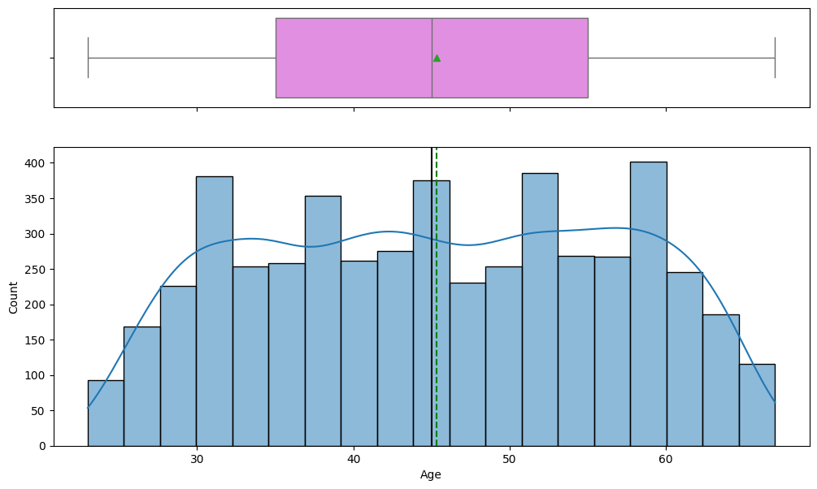

```python
histogram_boxplot(data, "Age")
```

### *Observation of Age* -

Histogram:

- The Age distribution appears to be fairly uniform, covering a wide range of ages from 23 to 67, with no strong skewness. There are slight peaks around certain age groups, suggesting a relatively even distribution of customers across adult ages.

Q1 . `What is the distribution of mortgage attribute? Are there any noticeable patterns or outliers in the distribution?`

### *Observation on Mortgage*

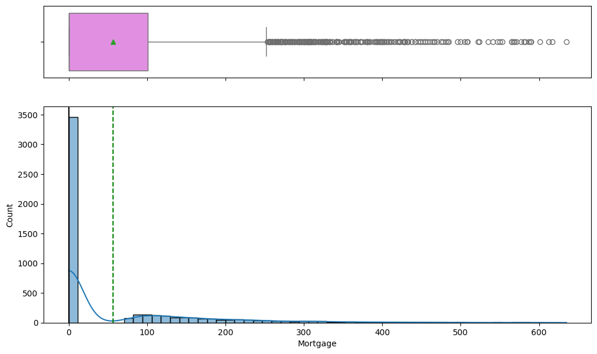

```python
# Histogram for Mortgage
histogram_boxplot(data, "Mortgage")
```

### *Observation*

Univariate plots for the Mortgage attribute:

Histogram:

- The histogram clearly shows a very large peak at 0, indicating that a significant number of customers have no mortgage.
- For those with a mortgage, the distribution appears right-skewed, with fewer customers having very high mortgage values.

### *Observation on Experience*

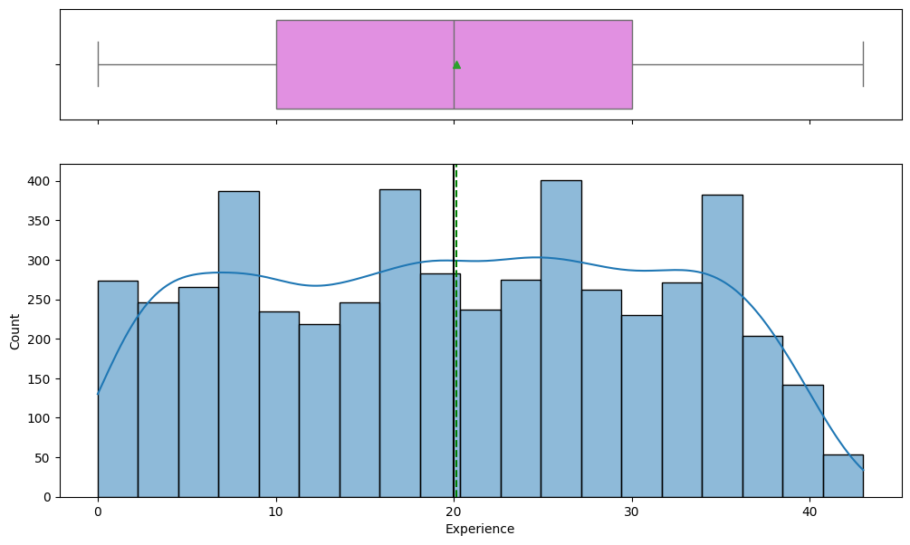

```python
histogram_boxplot(data, "Experience")
```

### *Observation*

Univariate plots for the Experience attribute:

- Histogram: The distribution of Experience appears to be fairly uniform, similar to Age, covering a wide range of professional years.
- We can see a good spread across different experience levels, which is expected.

#### Univariate Analysis for Numerical Features: CCAvg

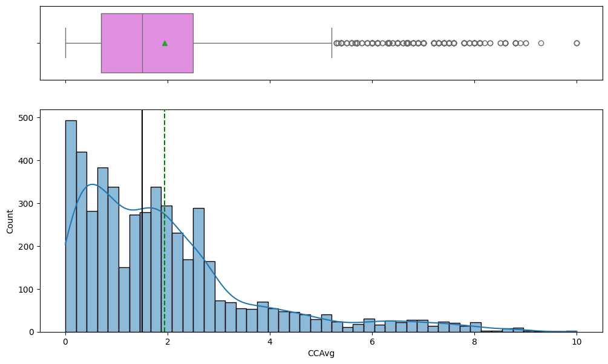

```python
# Histogram for CCAvg
histogram_boxplot(data, "CCAvg")
```

### *Observations*

- Histogram: The CCAvg distribution is heavily right-skewed, with a large concentration of customers having low average credit card spending. There's a long tail indicating a few customers with very high spending.

### *Univariate Analysis : Income*

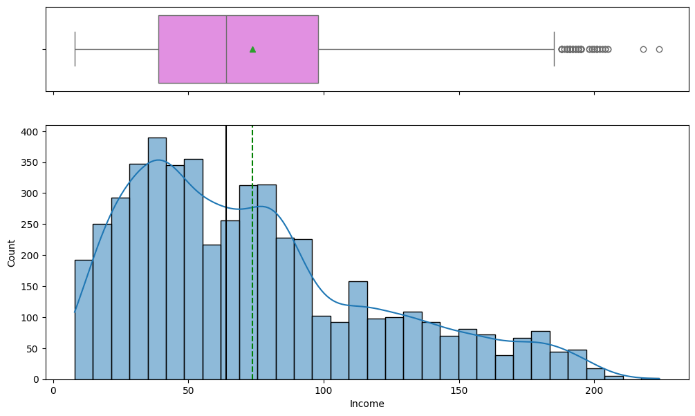

```python
# Histogram for income
histogram_boxplot(data, "Income")
```

### *Observation*

Histogram -

- The distribution of Income appears to be right-skewed, meaning most customers have lower to moderate incomes, and there's a long tail extending towards higher incomes. This pattern is common in income distributions.

#### Univariate Analysis for Categorical Features: Family

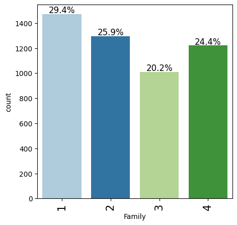

```python
# Count plot for Family
labeled_barplot(data, "Family", perc=True)
```

### Q2.`How many customers have credit cards?`

```
Number of customers with credit cards (1) and without (0):
CreditCard
0    3530
1    1470
Name: count, dtype: int64
```

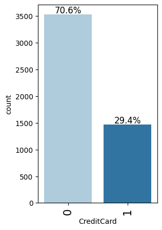

```python
# Count the number of customers with and without credit cards
credit_card_counts = data['CreditCard'].value_counts()
print("Number of customers with credit cards (1) and without (0):")
print(credit_card_counts)

# Visualize the distribution
labeled_barplot(data, 'CreditCard', perc=True)
```

### *Observation -*

Based on our analysis, we found that:

- 3530 customers do not have a credit card issued by another bank (CreditCard = 0), which is 70.6% of the total.
- 1470 customers do have a credit card issued by another bank (CreditCard = 1), which is 29.4% of the total.

This means that 1470 customers in our dataset use a credit card from another bank.

### Q3.* What are the attributes that have a strong correlation with the target attribute (personal loan)?*

```
Correlation with Personal_Loan:
Personal_Loan    1.000000
Income           0.502462
CCAvg            0.366889
Mortgage         0.142095
Family           0.061367
Age             -0.007726
Experience      -0.008304
ID              -0.024801
Name: Personal_Loan, dtype: float64
```

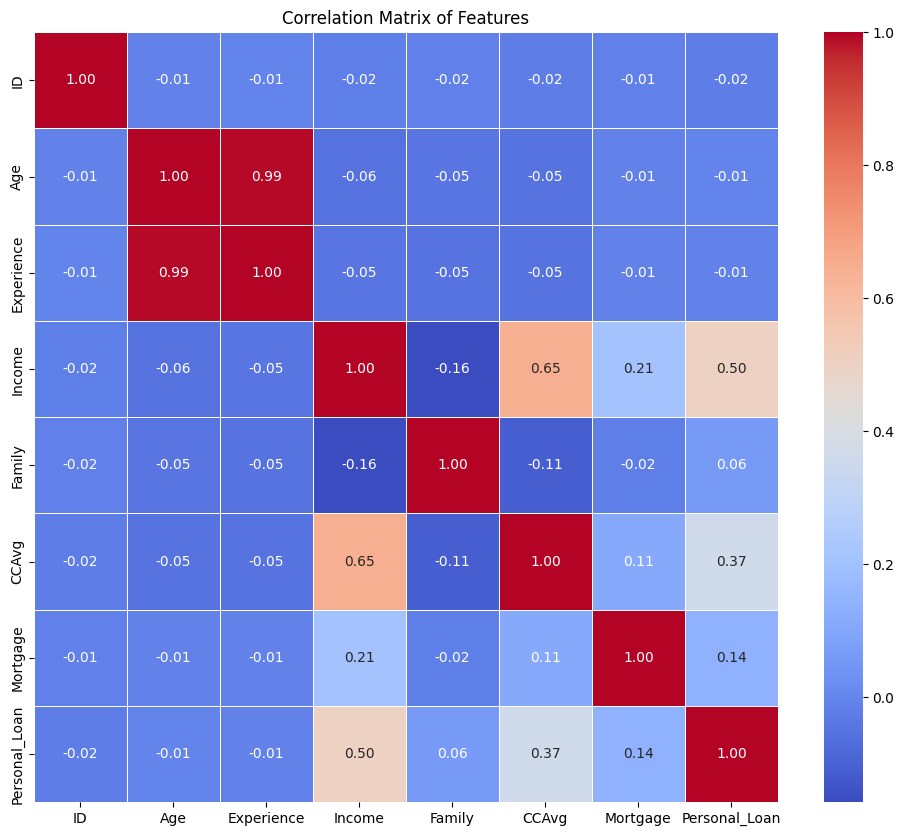

```python
# Calculate the correlation matrix
correlation_matrix = data.corr(numeric_only=True)

# Filter correlation with Personal_Loan
loan_correlation = correlation_matrix['Personal_Loan'].sort_values(ascending=False)
print("Correlation with Personal_Loan:")
print(loan_correlation)

# Visualize the correlation matrix as a heatmap
plt.figure(figsize=(12, 10))
sns.heatmap(correlation_matrix, annot=True, fmt=".2f", cmap='coolwarm', linewidths=.5)
plt.title('Correlation Matrix of Features')
plt.show()
```

### *Observation*

The observations from the correlation analysis with Personal_Loan:

From the loan_correlation output, sorted in descending order, following observations list below:

- `Income (0.50):` This shows a moderately strong positive correlation with Personal_Loan. This suggests that customers with higher incomes are more likely to accept a personal loan.
- `CCAvg (0.37):` There is a positive, moderate correlation between average credit card spending and Personal_Loan. Customers who spend more on credit cards might be more inclined to take out a personal loan.
- `Mortgage (0.14):` A weak positive correlation exists, indicating a slight tendency for customers with a mortgage to accept personal loans, but it's not a strong driver.
- `Family (0.06):` This has a very weak positive correlation, suggesting family size is not a significant predictor of loan acceptance. Age, Experience, ID: These features show very weak or negligible correlations with Personal_Loan (close to 0 or slightly negative), indicating they are not strong linear predictors of loan acceptance.

**Overall from the Heatmap:** The heatmap visually reinforces these findings. The strongest positive correlations with Personal_Loan are clearly visible for Income and CCAvg, appearing as warmer colors. Other features show much weaker correlations, closer to white or light blue, confirming their limited linear relationship with the target variable.

This analysis highlights Income and CCAvg as potentially very important factors in predicting Personal_Loan acceptance.

### *Q4.`How does a customer's interest in purchasing a loan vary with their education?`*

The stacked_barplot function was defined to help visualize the relationship between a categorical predictor variable and our binary target variable, Personal_Loan. It prints cross-tabulations (counts and proportions) and then generates a stacked bar chart.

```
Cross-tabulation (Counts):
Personal_Loan     0    1   All
Education
All            4520  480  5000
3              1296  205  1501
2              1221  182  1403
1              2003   93  2096
------------------------------------------------------------------------------------------------------------------------
Cross-tabulation (Proportions):
Personal_Loan         0         1
Education
3              0.863424  0.136576
2              0.870278  0.129722
1              0.955630  0.044370
```

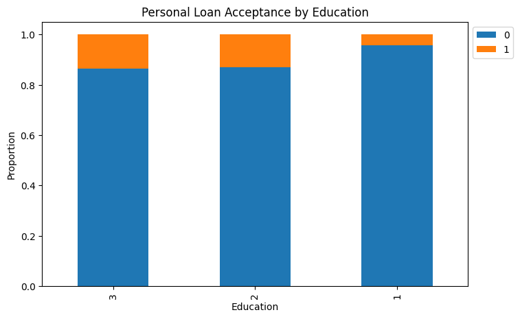

```
Cross-tabulation (Counts):
Personal_Loan          0    1   All
Securities_Account
All                 4520  480  5000
0                   4058  420  4478
1                    462   60   522
------------------------------------------------------------------------------------------------------------------------
Cross-tabulation (Proportions):
Personal_Loan              0         1
Securities_Account
1                   0.885057  0.114943
0                   0.906208  0.093792
```

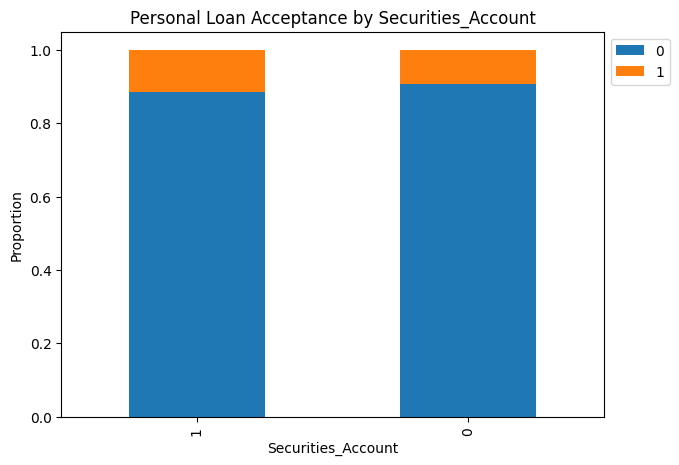

```
Cross-tabulation (Counts):
Personal_Loan     0    1   All
CD_Account
All            4520  480  5000
0              4358  340  4698
1               162  140   302
------------------------------------------------------------------------------------------------------------------------
Cross-tabulation (Proportions):
Personal_Loan         0         1
CD_Account
1              0.536424  0.463576
0              0.927629  0.072371
```

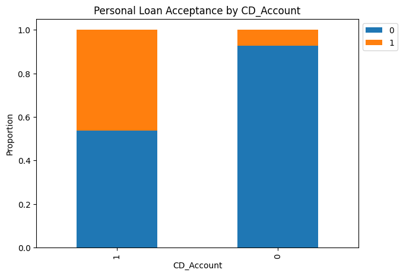

```
Cross-tabulation (Counts):
Personal_Loan     0    1   All
Online
All            4520  480  5000
1              2693  291  2984
0              1827  189  2016
------------------------------------------------------------------------------------------------------------------------
Cross-tabulation (Proportions):
Personal_Loan        0        1
Online
1              0.90248  0.09752
0              0.90625  0.09375
```

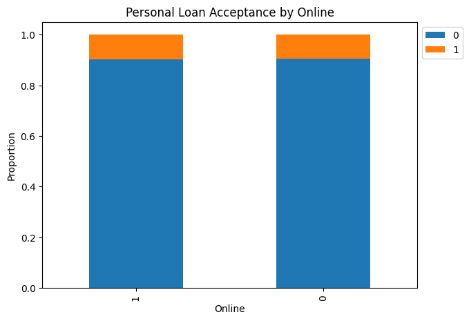

```
Cross-tabulation (Counts):
Personal_Loan     0    1   All
CreditCard
All            4520  480  5000
0              3193  337  3530
1              1327  143  1470
------------------------------------------------------------------------------------------------------------------------
Cross-tabulation (Proportions):
Personal_Loan         0         1
CreditCard
1              0.902721  0.097279
0              0.904533  0.095467
```

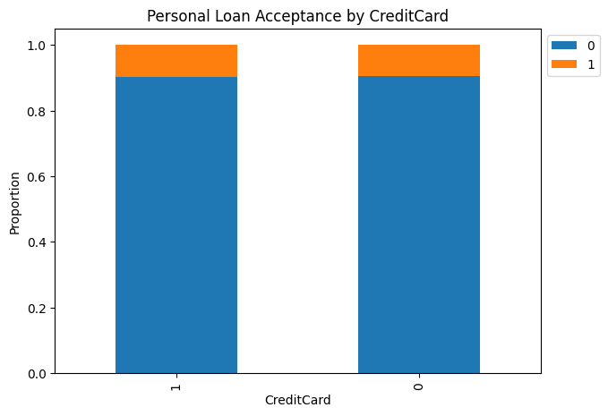

```
Cross-tabulation (Counts):
Personal_Loan     0    1   All
ZIPCode
All            4520  480  5000
94             1334  138  1472
92              894   94   988
95              735   80   815
90              636   67   703
91              510   55   565
93              374   43   417
96               37    3    40
------------------------------------------------------------------------------------------------------------------------
Cross-tabulation (Proportions):
Personal_Loan         0         1
ZIPCode
93             0.896882  0.103118
95             0.901840  0.098160
91             0.902655  0.097345
90             0.904694  0.095306
92             0.904858  0.095142
94             0.906250  0.093750
96             0.925000  0.075000
```

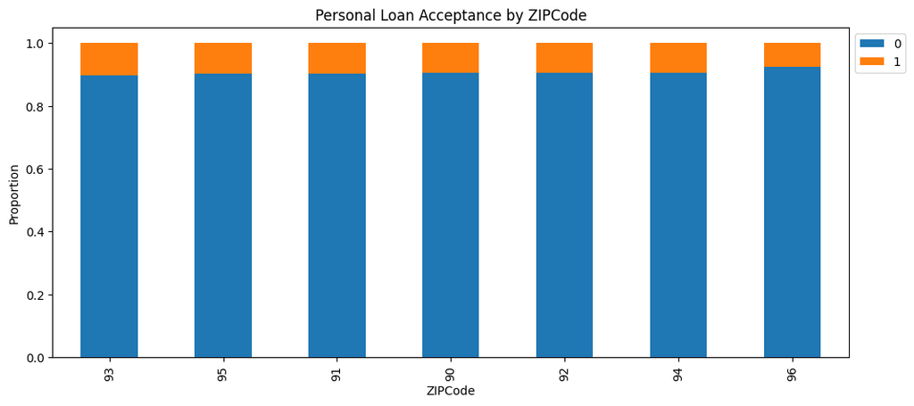

```
Cross-tabulation (Counts):
Personal_Loan     0    1   All
Family
All            4520  480  5000
4              1088  134  1222
3               877  133  1010
1              1365  107  1472
2              1190  106  1296
------------------------------------------------------------------------------------------------------------------------
Cross-tabulation (Proportions):
Personal_Loan         0         1
Family
3              0.868317  0.131683
4              0.890344  0.109656
2              0.918210  0.081790
1              0.927310  0.072690
```

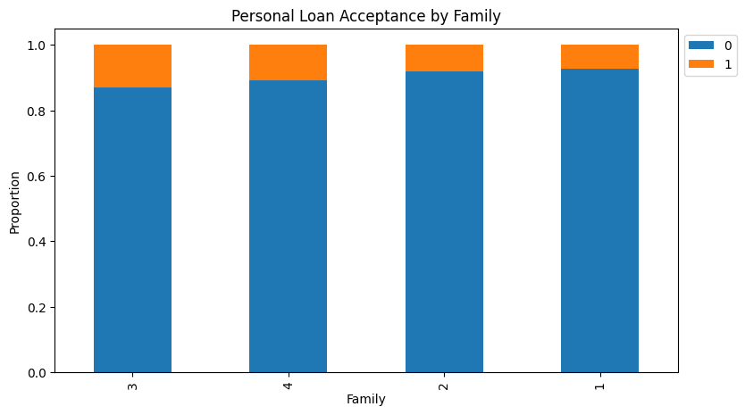

```python
def stacked_barplot(data, predictor, target):
    """
    Print the category counts and plot a stacked bar chart

    data: dataframe
    predictor: independent variable
    target: target variable
    """
    count = data[predictor].nunique()
    # Using the minority class for sorting, assuming 1 is 'Yes' for Personal_Loan
    sorter = data[target].value_counts().index[-1]
    tab1 = pd.crosstab(data[predictor], data[target], margins=True).sort_values(
        by=sorter, ascending=False
    )
    print("Cross-tabulation (Counts):")
    print(tab1)
    print("-" * 120)
    tab = pd.crosstab(data[predictor], data[target], normalize="index").sort_values(
        by=sorter, ascending=False
    )
    print("Cross-tabulation (Proportions):")
    print(tab)
    tab.plot(kind="bar", stacked=True, figsize=(count + 5, 5))
    plt.title(f'Personal Loan Acceptance by {predictor}')
    plt.xlabel(predictor)
    plt.ylabel('Proportion')
    plt.legend(
        loc="lower left", frameon=False,
    )
    plt.legend(loc="upper left", bbox_to_anchor=(1, 1))
    plt.show()

stacked_barplot(data, 'Education', 'Personal_Loan')
stacked_barplot(data, 'Securities_Account', 'Personal_Loan')
stacked_barplot(data, 'CD_Account', 'Personal_Loan')
stacked_barplot(data, 'Online', 'Personal_Loan')
stacked_barplot(data, 'CreditCard', 'Personal_Loan')
stacked_barplot(data, 'ZIPCode', 'Personal_Loan')
stacked_barplot(data, 'Family', 'Personal_Loan')
```

The observations for each categorial features that plotted against 'Personal_Loan':

1. `Education`:
- - Observation: Customers with higher education levels (Graduate and Advanced/Professional) are significantly more likely to accept a personal loan compared to those with an undergraduate degree. The acceptance rate is considerably higher for groups 2 and 3.
2. `Securities_Account:`
- - Observation: Customers who have a securities account (Securities_Account = 1) show a slightly higher proportion of personal loan acceptance compared to those who do not (Securities_Account = 0), though the difference is not very large.
3. `CD_Account:`
- - Observation: This is a very strong predictor! Customers who have a Certificate of Deposit (CD) account (CD_Account = 1) are much more likely to accept a personal loan (around 46% acceptance rate) compared to those who do not. This is a highly influential factor.
4. `Online:`
- - Observation: There is very little difference in personal loan acceptance rates between customers who use online banking (Online = 1) and those who do not (Online = 0). This suggests online banking usage is not a strong differentiating factor for loan acceptance.
5. `CreditCard:`
- - Observation: Similar to 'Online', there is almost no difference in personal loan acceptance rates between customers who have a credit card from another bank (CreditCard = 1) and those who do not (CreditCard = 0). This attribute also doesn't appear to be a strong predictor.
6. `ZIPCode (First two digits):`
- - Observation: While there are slight variations, the proportion of personal loan acceptance across different ZIP Code prefixes is generally similar, mostly hovering around 9-10%. This suggests that the generalized geographical region (based on the first two ZIP code digits) does not strongly influence personal loan acceptance.
7. `Family:`
- - Observation: Family size appears to have some influence. Customers with a family size of 3 and 4 show slightly higher personal loan acceptance rates (around 13% and 11% respectively) compared to those with family sizes of 1 and 2 (around 7-8%). This indicates that larger families might be a bit more inclined to take out a personal loan.
- `Overall, 'CD_Account' and 'Education'` (specifically higher levels) show the most significant positive association with 'Personal_Loan' acceptance among these categorical features.